# Think like a programmer - an introduction

At this point, you can add more specifications such as the colour, for example:

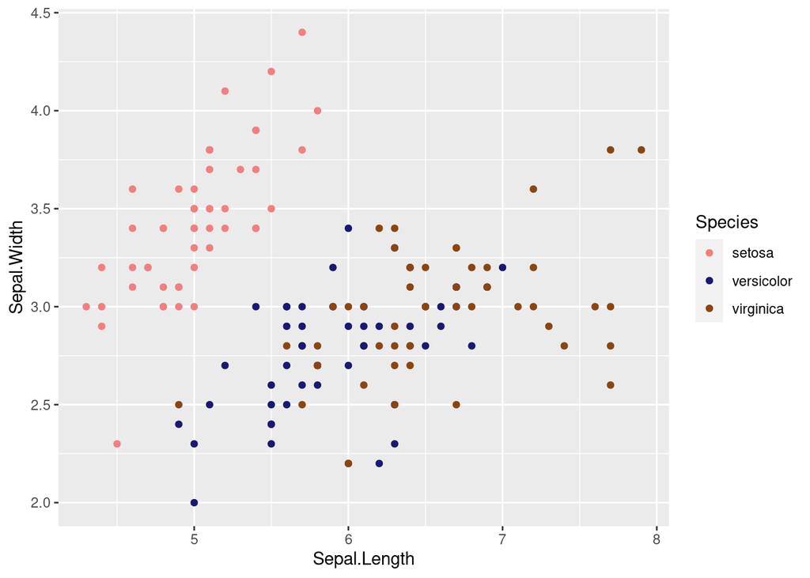

```r
# plot using dots
ggplot(a_nice_table, aes(x=Sepal.Length, y=Sepal.Width)) +
  geom_point(aes(colour=Species)) +
  scale_colour_manual(values=c("lightcoral", "midnightblue", "saddlebrown"))
```

Now, add some order to the labels, if you like. That’s where **factors** become interesting:

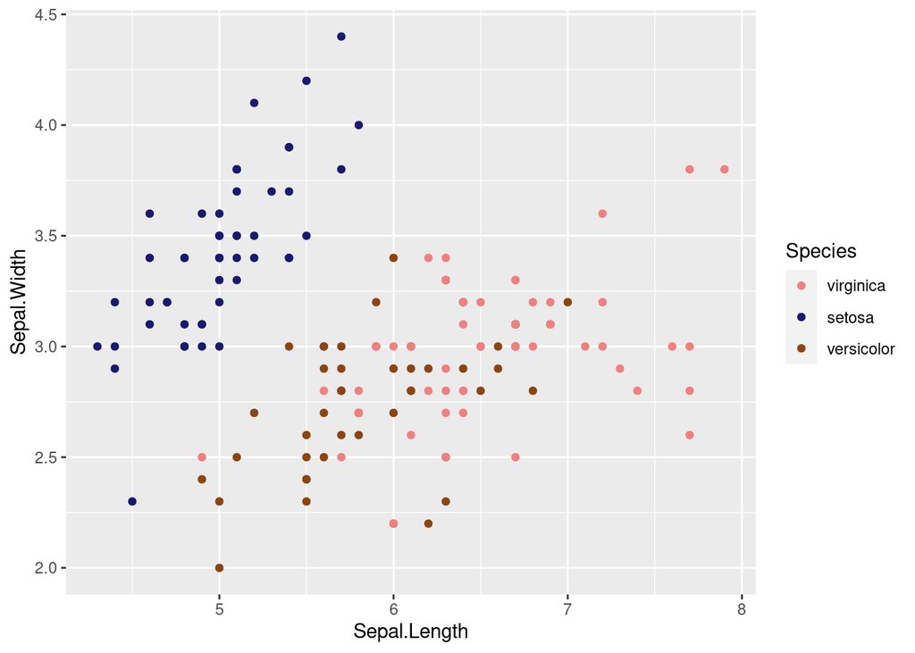

```r
# load a table from a csv file
a_nice_table <- read.csv("/home/gabriele/work/microbiology/think_like_a_programmer/R_foundations/lessons_files/data/a_nicely_formatted_table.csv", header=T, sep=",")

# set order of levels for the colouring
a_nice_table$Species <- factor(a_nice_table$Species, levels=c("virginica", "setosa", "versicolor"))

# plot using dots
ggplot(a_nice_table, aes(x=Sepal.Length, y=Sepal.Width)) +
  geom_point(aes(colour=Species)) +
  scale_colour_manual(values=c("lightcoral", "midnightblue", "saddlebrown"))
```

Finally, change the style using `themes` and `labels` of the plot.

As you can see, a palette with three colours was defined. Then, using the function `names()`, the species were mapped to the colours. This is fundamental for `ggplot2` to know which colour will be used for which species.

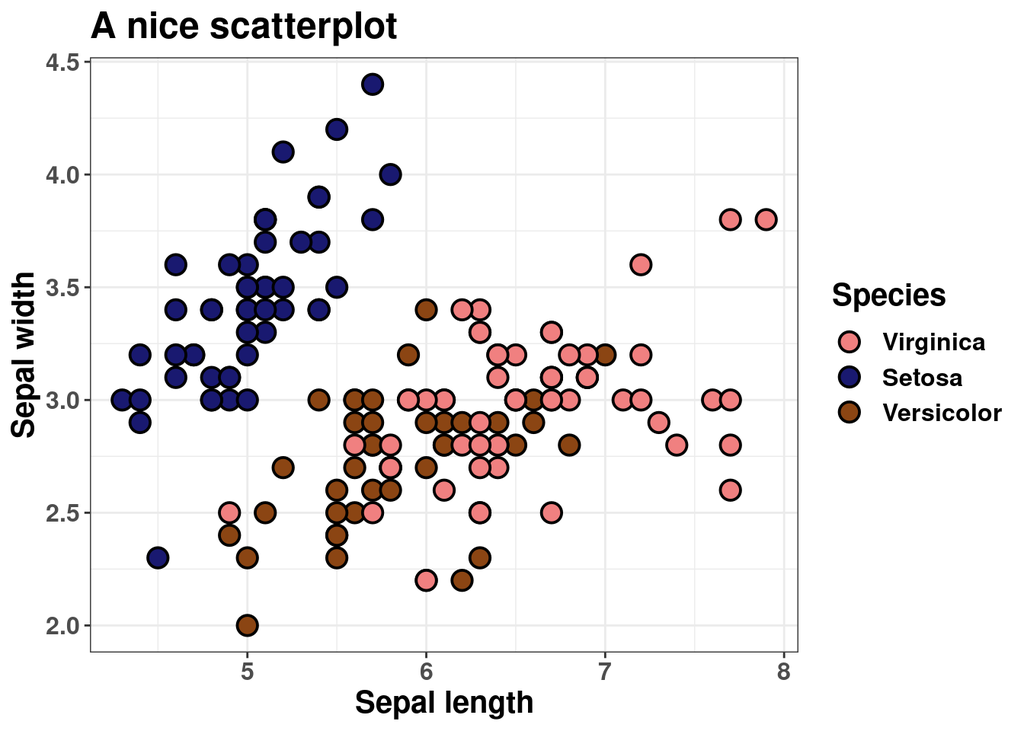

```r
# load a table from a csv file
a_nice_table <- read.csv("/home/gabriele/work/microbiology/think_like_a_programmer/R_foundations/lessons_files/data/a_nicely_formatted_table.csv", header=T, sep=",")

# set order of levels for the colouring
a_nice_table$Species <- factor(a_nice_table$Species, levels=c("virginica", "setosa", "versicolor"))
levels(a_nice_table$Species) <- c("Virginica", "Setosa", "Versicolor")

# define palette
palette <- c("lightcoral", "midnightblue", "saddlebrown")
# define names of each colour to map species to colour
names(palette) <- levels(a_nice_table$Species)

# plot using dots
ggplot(a_nice_table, aes(x=Sepal.Length, y=Sepal.Width, fill=Species)) +
    geom_point(size=4, stroke=1, color="black", shape=21) +
    scale_fill_manual(values=palette) +
    guides(fill=guide_legend(override.aes=list(shape=21))) +
  xlab("Sepal length") +
  ylab("Sepal width") +
  ggtitle("A nice scatterplot") +
  theme_bw() +
  theme(text=element_text(size=15, face="bold"), legend.position="right")
```

# Solutions to exercises in lesson 04

### If-else

```r
# load contacts
contact_list <- read.csv("/home/gabriele/work/microbiology/think_like_a_programmer/R_foundations/lessons_files/data/contacts_list.csv", header=T, sep="\t")

# define two random person names
a_person <- "Silvia"
a_person <- "Elena"

# find a_person in the contact list
person_index <- which(contact_list$name==a_person)

# was someone found?
if (length(person_index) > 0) {
  print(paste(a_person, "phone n. is:", contact_list$phone[person_index], sep=" "))
} else {
  print(paste(a_person, "was not found.", sep=" "))
}

# ifelse() version
ifelse(a_person %in% contact_list$name, paste(a_person, "phone n. is:", contact_list$phone[which(contact_list$name==a_person)], sep=" "), paste(a_person, "was not found.", sep=" "))
```

### For and While

When we discussed how to write a function to compute the average of a set of values, we started doing it for vectors of two, and then we generalised to any vector.

To generalise, we used the function `sum()`.

Can you replicate what the function `sum()` is doing:

- using a `for` loop?

```r
sum_for <- function(a_vector){

  # define variable at 0
  total_sum <- 0

  # loop through the vector's values
  for (a_value in a_vector) {
    # sum the current value to zero
    total_sum <- total_sum + a_value
  }

  # return the total sum
  return(total_sum)
}
```

- using a `while` loop?

```r
sum_while <- function(a_vector){

  # define variable at 0
  total_sum <- 0

  # loop through the vector's values
  while (length(a_vector)!=0) {
    # sum the current value to zero
    total_sum <- total_sum + a_vector[length(a_vector)]

    # remove the value that was just summed from
    # the vector
    a_vector <- a_vector[-length(a_vector)]
  }

  # return the total sum
  return(total_sum)
}
```

Can you use the loop to re-write the `arithmetic_mean()` function?

```r
# define the function average for two values
# however by default, a_set_of_values will be equal to
# the vector c(6, 8) and the function, if no input was
# specified, will return 7, which is the average of 6 and 8
arithmetic_mean <- function(a_set_of_values=c(6, 8)) {
  # sum_for the two values and divide by the number of values
  the_sum <- sum_for(a_set_of_values)

  # sum_for the two values and divide by the number of values
  the_sum <- sum_while(a_set_of_values)

  # compute the number of values in the vector
  the_n_of_vals <- length(a_set_of_values)
  # compute the average
  average <- the_sum/the_n_of_vals
  # return the average value you just computed
  return(average)
}

# run function with no input: default values will be used
arithmetic_mean()
# run function with input: default will not be used
# instead the average of 10 and 3 will be returned
arithmetic_mean(c(10, 3))
```

# Final exercise

Load the data, i.e. `counts_final.csv` and `metadata_final.csv` tables

1. difficult to visualise, easy to plot: for each phylum plot the abundances (that are stored in the counts table), to compare treatment and controls, in winter and summer, DNA and RNA (these info are stored in the metadata table);
2. medium to easy to visualise if you did n. 1. difficult to plot (probably): visualise the variables vegetation and pH together to see if they are correlated (use a scatterplot, for example). Colour the data points by phylum. Or color them by season, or treatment, or DNA/RNA Or you can colour with a variable and shape with another variable. Or, and this is what I suggest to do, is to create two plots, one for DNA, one for RNA, and to colour by treatment, and shape by season. The phylum can be added as a label. To add labels in a `ggplot2` plot, you may want to check out `geom_text()`.